# Meta Heuristics 2

Evan Carey

# Overview

- Overview of metaheuristics
- Random search implementation
- Genetic algorithm implementation

# Data import

- First import the data as before.

```r
## import Missouri FQHC shapefile
library(rgdal)
data_path <- 'MO_2018_Federally_Qualified_Health_Center_Locations'
MO_FQHC <-
  readOGR(data_path,
          'MO_2018_Federally_Qualified_Health_Center_Locations')
## create data.table for later use
library(data.table)
MO_FQHC_df <- data.table(as.data.frame(MO_FQHC))
```

```r
## examine data
class(MO_FQHC)
```

```
## [1] "SpatialPointsDataFrame"
## attr(,"package")
## [1] "sp"
```

```r
summary(MO_FQHC)
```

```
## Object of class SpatialPointsDataFrame
## Coordinates:
##                 min       max
## coords.x1 -95.23779 -89.38704
## coords.x2  36.23222  40.43782
## Is projected: FALSE
## proj4string : [+proj=longlat +datum=WGS84 +no_defs]
## Number of points: 197
## Data attributes:
##    OBJECTID          Group_Name          Facility           Address
##  Length:197         Length:197         Length:197         Length:197
##  Class :character   Class :character   Class :character   Class :character
##  Mode  :character   Mode  :character   Mode  :character   Mode  :character
##
##
##
##      City              County             State               Zip
##  Length:197         Length:197         Length:197         Length:197
##  Class :character   Class :character   Class :character   Class :character
##  Mode  :character   Mode  :character   Mode  :character   Mode  :character
##
##
##
##     Phone              Latitude       Longitude        Loc_Code
##  Length:197         Min.   :36.23   Min.   :-95.24   Length:197
##  Class :character   1st Qu.:37.21   1st Qu.:-93.80   Class :character
##  Mode  :character   Median :38.44   Median :-92.43   Mode  :character
##                     Mean   :38.24   Mean   :-92.24
##                     3rd Qu.:39.06   3rd Qu.:-90.43
##                     Max.   :40.44   Max.   :-89.39
```

```r
head(MO_FQHC)
```

```
##             coordinates OBJECTID                     Group_Name
## 1 (-90.55472, 38.43597)        1                        COMTREA
## 2 (-91.13403, 37.71462)        2 Missouri Highlands Health Care
## 3 (-92.60144, 38.16025)        3  Central Ozarks Medical Center
## 4 (-90.45724, 36.77261)        4 Missouri Highlands Health Care
## 5  (-94.49886, 38.9629)        5          Swope Health Services
## 6 (-91.35847, 37.14414)        6 Missouri Highlands Health Care
##                                                       Facility
## 1                            COMTREA Byrnes Mill Health Center
## 2                                      Viburnum Medical Clinic
## 3                    Central Ozarks Medical Center At The Lake
## 4 Missouri Highland Medical Clinic - Poplar Bluff Medical Park
## 5                                   Swope Health Hickman Mills
## 6                                 Shannon County Family Clinic
##                                Address          City    County State   Zip
## 1           100 Osage Executive Circle House Springs Jefferson    MO 63051
## 2              18 Viburnum Center Road      Viburnum      Iron    MO 65566
## 3                 3870 Columbia Avenue   Osage Beach    Miller    MO 65065
## 4 225 Physicians Park Drive, Suite 303  Poplar Bluff    Butler    MO 63901
## 5            8800 Blue Ridge Boulevard   Kansas City   Jackson    MO 64138
## 6                  1003 S. Main Street      Eminence   Shannon    MO 65466
##        Phone Latitude Longitude Loc_Code
## 1 6367893372 38.43595 -90.55468      MAP
## 2 5732445406 37.71462 -91.13398      MAP
## 3 5733027490 38.16026 -92.60146      MAP
## 4 5737856536 36.77257 -90.45721      MAP
## 5 8163213200 38.96288 -94.49885      MAP
## 6 5732265505 37.14414 -91.35846      MAP
```

```r
names(MO_FQHC)
```

```
##  [1] "OBJECTID"   "Group_Name" "Facility"   "Address"    "City"
##  [6] "County"     "State"      "Zip"        "Phone"      "Latitude"
## [11] "Longitude"  "Loc_Code"
```

# Function for calculating route distance

- We need the function to calculate the route distance we developed in the prior code:

```r
# write function to calculate the distance for a single route (i'th route)
path_dist_func <-
  function(pathVec,distMat) {
    temp_mat_path <-
      rbind(pathVec[-length(pathVec)],
            pathVec[-1])
    dist <- sum(apply(X = temp_mat_path,
                      MARGIN = 2,
                      FUN = function(x) distMat[x[1],x[2]]))
    return(dist)
}
```

# Random Paramater Space Searching

- Let’s say we are interested in identifying the shortest path to visit 20 FQHC’s
- We cannot search the full parameter space, it would take too long:

```r
factorial(20)/2
```

```
## [1] 1.216451e+18
```

- that is 1.2 **quintillion** numbers to search. If you could search 1000 combinations per second, it would still take you:

```r
n_calculations <- factorial(20)/2
seconds <- n_calculations/1000
seconds_in_a_year <- 60*60*24*365
years <- seconds/seconds_in_a_year
years
```

```
## [1] 38573408
```

**38 million years.**

- We could consider simply randomly searching the parameter space for some amount of time to see how far we get!
- Let’s first identify the subset of 20 sites

```r
## instead of searching every solution, let's just search some of the solution space.
## start with random search?
## 100 random paths using 20 sites:
## subset to 20
sites20 <-
  MO_FQHC_df[1:20,
             list(OBJECTID=as.character(OBJECTID),Longitude,Latitude)]
sites20
```

```
##     OBJECTID Longitude Latitude
##  1:        1 -90.55468 38.43595
##  2:        2 -91.13398 37.71462
##  3:        3 -92.60146 38.16026
##  4:        4 -90.45721 36.77257
##  5:        5 -94.49885 38.96288
##  6:        6 -91.35846 37.14414
##  7:        7 -93.37882 38.26586
##  8:        8 -90.77489 37.92027
##  9:        9 -92.92491 37.16020
## 10:       10 -93.99901 39.73522
## 11:       11 -91.14865 38.80012
## 12:       12 -91.95983 38.82981
## 13:       13 -93.21612 39.09904
## 14:       14 -94.36622 36.82241
## 15:       15 -94.44264 36.66941
## 16:       16 -94.44264 36.66941
## 17:       17 -93.88071 36.70019
## 18:       18 -93.88071 36.70019
## 19:       19 -94.53231 37.08676
## 20:       20 -94.53231 37.08676
```

- Next we create a distance matrix for use in the algorithm:

```r
## create distance matrix
library(geosphere)
dist_mat20 <-
  distm(sites20[,list(Longitude,Latitude)],
        fun=distHaversine)/1609.344
colnames(dist_mat20) <- sites20$OBJECTID
rownames(dist_mat20) <- sites20$OBJECTID
dist_mat20
```

```
##            1         2         3         4         5         6         7
## 1    0.00000  59.02925 112.73168 115.18096 215.99839  99.57211 153.64162
## 2   59.02925   0.00000  85.78468  75.06560 201.92948  41.34221 128.17465
## 3  112.73168  85.78468   0.00000 151.88753 116.67534  97.84479  42.87478
## 4  115.18096  75.06560 151.88753   0.00000 267.64939  56.05368 190.67064
## 5  215.99839 201.92948 116.67534 267.64939   0.00000 212.30788  77.38737
## 6   99.57211  41.34221  97.84479  56.05368 212.30788   0.00000 135.06861
## 7  153.64162 128.17465  42.87478 190.67064  77.38737 135.06861   0.00000
## 8   37.62587  24.23558 100.88033  81.28639 214.23631  62.50421 143.74913
## 9  156.74002 105.57212  71.40610 138.98820 151.30796  86.36715  80.41126
## 10 205.58953 208.39704 132.36069 281.03250  59.73969 229.29826 106.96390
## 11  40.80458  75.08905  90.26178 145.25005 180.73422 115.11533 126.19930
## 12  80.66437  89.22680  57.89192 164.29238 136.99137 121.11979  86.10490
## 13 150.67989 148.00356  72.93657 220.31779  69.56350 168.82103  58.29672
## 14 236.73050 188.30992 133.95205 216.52884 148.23455 167.66792 113.58293
```

[output cut: 48 more lines]

- Finally, let’s implement code to randomly sample 2k paths to search:

```r
## generate random list of 2k paths to search (using all 20 sites):
set.seed(32)
## one at a time
sample(sites20$OBJECTID,replace=F,size=20)
```

```
##  [1] "6"  "11" "9"  "18" "8"  "1"  "7"  "19" "3"  "20" "15" "14" "2"  "10" "12"
## [16] "17" "5"  "16" "4"  "13"
```

```r
sample(sites20$OBJECTID,replace=F,size=20)
```

```
##  [1] "6"  "5"  "3"  "8"  "19" "9"  "10" "14" "13" "12" "16" "11" "4"  "7"  "20"
## [16] "17" "1"  "15" "2"  "18"
```

```r
## Now do 2k
paths_1k <-
  unique(t(sapply(1:2000,
           function(x) sample(sites20$OBJECTID,replace=F,size=20))))
```

- Now that we have generated 2k random paths, we can calculate the distance for each path and find the minimum distance:

```r
## calculate distances for these paths
paths_1k_df <- data.table(paths_1k)
## find minimum
paths_1k_df$distance <-
  apply(paths_1k,
            MARGIN = 1,
            FUN = path_dist_func,
            distMat = dist_mat20)
paths_1k_df[distance == min(distance)]
```

```
##    V1 V2 V3 V4 V5 V6 V7 V8 V9 V10 V11 V12 V13 V14 V15 V16 V17 V18 V19 V20
## 1: 18  7 17 19 16  5 20 14 10  15   9   3   6   4   2  11   8   1  12  13
##    distance
## 1: 1740.999
```

- We can visualize our answers with a graph:

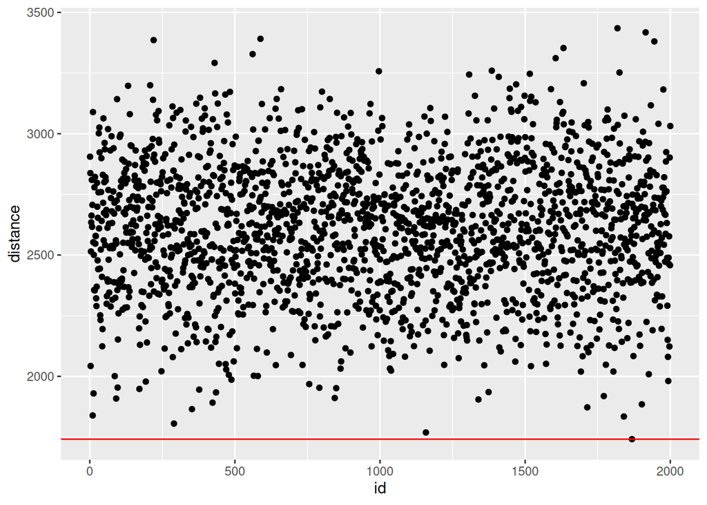

```r
## create graph of our answers:
paths_1k_df[,id:=1:.N]
library(ggplot2)
ggplot(paths_1k_df,aes(x=id,y=distance)) +
  geom_point() +
  geom_hline(yintercept=min(paths_1k_df$distance),color='red')
```

# Genetic Algorithms

- A better metaheuristic to use is a genetic algorithm. We can use the GA package in R to solve these sorts of problems.
- Since this function will maximize rather than minimize, I define the objective function (fitness function) as 1/cost (so max is the min cost)

```r
## Implement a genetic algorithm!
## must add fitness function to maximize, inverse of route distance (since we want to minimize distance)
library(GA)
Fitness_f <-
  function(pathVec,...) 1/path_dist_func(pathVec, ...)
gaobj <- ga(type = "permutation", fitness = Fitness_f,
         distMat = dist_mat20,lower = 1, upper = 20,
         popSize = 10, maxiter = 1000, run = 100, pmutation = 0.2)
```

- We can summarize the path the GA has taken, and graph the fitness of the population at every generation

```r
## summarize results
summary(gaobj)
```

```
## ── Genetic Algorithm ───────────────────
##
## GA settings:
## Type                  =  permutation
## Population size       =  10
## Number of generations =  1000
## Elitism               =  1
## Crossover probability =  0.8
## Mutation probability  =  0.2
##
## GA results:
## Iterations             = 310
## Fitness function value = 0.001007338
## Solution =
##      x1 x2 x3 x4 x5 x6 x7 x8 x9 x10  ...  x19 x20
## [1,] 15 16 14 20 19 17 18  9 11   1        13  12
```

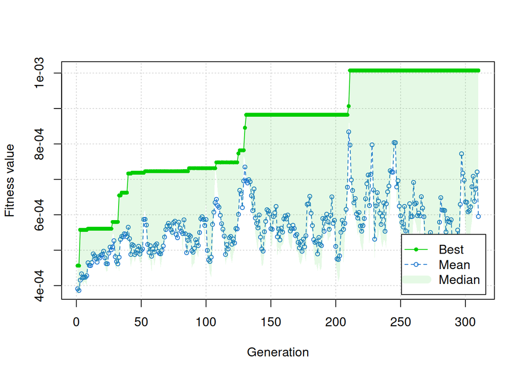

```r
plot(gaobj)
```

- If we want to double check things, we can extract the best solution like so:

```r
## extract best solution
gaobj@solution
```

```
##      x1 x2 x3 x4 x5 x6 x7 x8 x9 x10 x11 x12 x13 x14 x15 x16 x17 x18 x19 x20
## [1,] 15 16 14 20 19 17 18  9 11   1   2   4   6   8   3   7   5  10  13  12
```

```r
## extract fitness of best solution
1/gaobj@fitnessValue
```

```
## [1] 992.7153
```

- Then we can run the solution through our code to calculate the distance. Did the GA do better than our random search?

```r
## check we get the same answer
path1 <-
  as.character(gaobj@solution[1,])
path_dist_func(path1,dist_mat20) # Yes!
```

```
## [1] 992.7153
```